# Trabajo Final: Curso de NLP

*Amazon Books Reviews*

A continuación se presentan los resultados del trabajo final en el marco del curso de NLP. Consta de 5 secciones: Análisis Exploratorio de Datos, Análisis de Sentimientos, Clusters de Texto, Clasificación de Texto, and Sistema de Recomendaciones.

```python
import numpy as np # linear algebra
import pandas as pd # data processing, CSV file I/O (e.g. pd.read_csv)
import matplotlib.pyplot as plt
from wordcloud import WordCloud
import seaborn as sns
import missingno as msno
import nltk
import plotly.graph_objects as go
from vaderSentiment.vaderSentiment import SentimentIntensityAnalyzer
from sklearn.model_selection import train_test_split
from sklearn.feature_extraction.text import TfidfVectorizer
from sklearn.linear_model import LogisticRegression
from sklearn.metrics import classification_report
from sklearn.metrics import confusion_matrix, ConfusionMatrixDisplay
from sklearn.tree import DecisionTreeClassifier
from sklearn.naive_bayes import GaussianNB
from sklearn.ensemble import RandomForestClassifier
from sklearn.linear_model import LogisticRegression
from imblearn.over_sampling import SMOTE
```

```python
# Subir el archivo kaggle.json
from google.colab import files
files.upload()  # Upload the kaggle.json file from your computer

# Mover el archivo kaggle al lugar correspondiente
!mkdir -p ~/.kaggle
!cp kaggle.json ~/.kaggle/
!chmod 600 ~/.kaggle/kaggle.json

# Instalar Kaggle CLI
!pip install -q kaggle

# Descargar los datasets
!kaggle datasets download -d mohamedbakhet/amazon-books-reviews

# Descomprimir los datasets
!unzip amazon-books-reviews.zip
```

Upload widget is only available when the cell has been executed in the current browser session. Please rerun this cell to enable.

```
Saving kaggle.json to kaggle (1).json
Dataset URL: https://www.kaggle.com/datasets/mohamedbakhet/amazon-books-reviews
License(s): CC0-1.0
amazon-books-reviews.zip: Skipping, found more recently modified local copy (use --force to force download)
Archive:  amazon-books-reviews.zip
replace Books_rating.csv? [y]es, [n]o, [A]ll, [N]one, [r]ename: a
error:  invalid response [a]
replace Books_rating.csv? [y]es, [n]o, [A]ll, [N]one, [r]ename: y
  inflating: Books_rating.csv        y

replace books_data.csv? [y]es, [n]o, [A]ll, [N]one, [r]ename:   inflating: books_data.csv
```

```python
# Cargar librerias
df_books = pd.read_csv('books_data.csv')
df_reviews = pd.read_csv('Books_rating.csv')
```

## Análisis Exploratorio de Datos

### a. Información general de los datasets

*Dataset: Información libros*

```python
# Mostrar las primeras filas
df_books.head()
```

|  | Title | description | authors | image | previewLink | publisher | publishedDate | infoLink | categories | ratingsCount |
| --- | --- | --- | --- | --- | --- | --- | --- | --- | --- | --- |
| 0 | Its Only Art If Its Well Hung! | NaN | ['Julie Strain'] | http://books.google.com/books/content?id=DykPA... | http://books.google.nl/books?id=DykPAAAACAAJ&d... | NaN | 1996 | http://books.google.nl/books?id=DykPAAAACAAJ&d... | ['Comics & Graphic Novels'] | NaN |
| 1 | Dr. Seuss: American Icon | Philip Nel takes a fascinating look into the k... | ['Philip Nel'] | http://books.google.com/books/content?id=IjvHQ... | http://books.google.nl/books?id=IjvHQsCn_pgC&p... | A&C Black | 2005-01-01 | http://books.google.nl/books?id=IjvHQsCn_pgC&d... | ['Biography & Autobiography'] | NaN |
| 2 | Wonderful Worship in Smaller Churches | This resource includes twelve principles in un... | ['David R. Ray'] | http://books.google.com/books/content?id=2tsDA... | http://books.google.nl/books?id=2tsDAAAACAAJ&d... | NaN | 2000 | http://books.google.nl/books?id=2tsDAAAACAAJ&d... | ['Religion'] | NaN |
| 3 | Whispers of the Wicked Saints | Julia Thomas finds her life spinning out of co... | ['Veronica Haddon'] | http://books.google.com/books/content?id=aRSIg... | http://books.google.nl/books?id=aRSIgJlq6JwC&d... | iUniverse | 2005-02 | http://books.google.nl/books?id=aRSIgJlq6JwC&d... | ['Fiction'] | NaN |
| 4 | Nation Dance: Religion, Identity and Cultural ... | NaN | ['Edward Long'] | NaN | http://books.google.nl/books?id=399SPgAACAAJ&d... | NaN | 2003-03-01 | http://books.google.nl/books?id=399SPgAACAAJ&d... | NaN | NaN |

```python
# Dimensiones del dataset
df_books.shape
```

```
(212404, 10)
```

```python
# Información del tipo de variables
df_books.info()
```

```
<class 'pandas.core.frame.DataFrame'>
RangeIndex: 212404 entries, 0 to 212403
Data columns (total 10 columns):
 #   Column         Non-Null Count   Dtype
---  ------         --------------   -----
 0   Title          212403 non-null  object
 1   description    143962 non-null  object
 2   authors        180991 non-null  object
 3   image          160329 non-null  object
 4   previewLink    188568 non-null  object
 5   publisher      136518 non-null  object
 6   publishedDate  187099 non-null  object
 7   infoLink       188568 non-null  object
 8   categories     171205 non-null  object
 9   ratingsCount   49752 non-null   float64
dtypes: float64(1), object(9)
memory usage: 16.2+ MB
```

De acuerdo con el output anterior, el dataset `df_books`, contiene la información de los libros de la base de datos de **Amazon**. En total se compone de 212,404 registros y 10 columnas, lo cuál lo convierte en un conjunto de datos amplio. El dataset cuenta con columnas como: `Title` (título del libro), `description` (sipnosis del contenido), `authores` (autores) y varios links con información adicional del libro (`image`, `previewLink`, `infolink`). También se encuentra información relacionada con la publicación del libro como `publisher` (la editorial), `publishedDate` (fecha de publicación), `categories` (etiquetas temáticas) y `ratingsCount` (número de reseñas).

De acuerdo con la información del tipo de datos, 9 de 10 columnas son de tipo `object`, es decir, contienen texto o listas codificadas como texto. Solo la columna `ratingsCount` es de tipo `float64`, lo que indica que almacena datos numéricos decimales. Sin embargo, muchas columnas presentan valores nulos. Por ejemplo, `ratingsCount` tiene apenas 49,752 valores no nulos de los más de 212 mil registros, lo que implica que alrededor del 76% de los libros no tienen información sobre calificaciones. Asimismo, columnas como `description`, `publisher`, `image` y `categories` también presentan una cantidad considerable de datos ausentes.

*Dataset: Información ratings*

```python
# Mostrar las primeras filas
df_reviews.head()
```

|  | Id | Title | Price | User_id | profileName | review/helpfulness | review/score | review/time | review/summary | review/text |
| --- | --- | --- | --- | --- | --- | --- | --- | --- | --- | --- |
| 0 | 1882931173 | Its Only Art If Its Well Hung! | NaN | AVCGYZL8FQQTD | Jim of Oz "jim-of-oz" | 7/7 | 4.0 | 940636800 | Nice collection of Julie Strain images | This is only for Julie Strain fans. It's a col... |
| 1 | 0826414346 | Dr. Seuss: American Icon | NaN | A30TK6U7DNS82R | Kevin Killian | 10/10 | 5.0 | 1095724800 | Really Enjoyed It | I don't care much for Dr. Seuss but after read... |
| 2 | 0826414346 | Dr. Seuss: American Icon | NaN | A3UH4UZ4RSVO82 | John Granger | 10/11 | 5.0 | 1078790400 | Essential for every personal and Public Library | If people become the books they read and if "t... |
| 3 | 0826414346 | Dr. Seuss: American Icon | NaN | A2MVUWT453QH61 | Roy E. Perry "amateur philosopher" | 7/7 | 4.0 | 1090713600 | Phlip Nel gives silly Seuss a serious treatment | Theodore Seuss Geisel (1904-1991), aka &quot;D... |
| 4 | 0826414346 | Dr. Seuss: American Icon | NaN | A22X4XUPKF66MR | D. H. Richards "ninthwavestore" | 3/3 | 4.0 | 1107993600 | Good academic overview | Philip Nel - Dr. Seuss: American IconThis is b... |

```python
# Dimensiones del dataset
df_reviews.shape
```

```
(3000000, 10)
```

```python
# Información del tipo de variables
df_reviews.info()
```

```
<class 'pandas.core.frame.DataFrame'>
RangeIndex: 3000000 entries, 0 to 2999999
Data columns (total 10 columns):
 #   Column              Dtype
---  ------              -----
 0   Id                  object
 1   Title               object
 2   Price               float64
 3   User_id             object
 4   profileName         object
 5   review/helpfulness  object
 6   review/score        float64
 7   review/time         int64
 8   review/summary      object
 9   review/text         object
dtypes: float64(2), int64(1), object(7)
memory usage: 228.9+ MB
```

El conjunto de datos de reseñas de libros contiene 3 millones de entradas y 10 columnas. En las primeras filas se observan variables clave como `Id`, `Title`, `User_id`, `profileName`, `review/score`, `review/time`, `review/summary` y `review/text`, que contienen información textual relevante sobre la opinión del usuario. Algunas columnas como `Price` contienen valores nulos (NaN).

Desde el punto de vista del tipo de variables, el dataset presenta una mezcla de datos categóricos (object), numéricos (float64, int64) y textos libres. Por ejemplo, `review/score` y `Price` están codificados como float64, mientras que `review/time` es int64.

### b. Ejemplo de la información contenida en los datasets

*Información de los libros*

```python
def book_sample(row):
    print("##########################################")
    print('\t\t\t{}\t\t\n\n'.format(row['Title']))
    print("description : "+str(row['description']))
    print("\n\n authors are "+str(row['authors']))
    try:
        io.imshow(io.imread(row['image']))
    except:
        print("can't read image maybe it's Null or don't have interent connection")
    try:
        print("\n\n previewLink is ")
        display(row['previewLink'])
    except:
        print("can't read previewLink maybe it's Null or don't have interent connection")
    try:
        print("\n\n infoLink is ")
        display(row['infoLink'])
    except:
        print("can't read infoLink maybe it's Null or don't have interent connection")
    print("\n\n publisher is "+str(row['publisher']))
    print("\n\n published Date is "+str(row['publishedDate']))
    print("\n\n categories are "+str(row['categories']))
    print("\n\n rating is "+str(row['ratingsCount']))
    print("##########################################")
```

```python
 book_sample(df_books.iloc[1,:])
```

```
##########################################
			Dr. Seuss: American Icon


description : Philip Nel takes a fascinating look into the key aspects of Seuss's career - his poetry, politics, art, marketing, and place in the popular imagination." "Nel argues convincingly that Dr. Seuss is one of the most influential poets in America. His nonsense verse, like that of Lewis Carr…


 authors are ['Philip Nel']
can't read image maybe it's Null or don't have interent connection


 previewLink is
```

```
'http://books.google.nl/books?id=IjvHQsCn_pgC&printsec=frontcover&dq=Dr.+Seuss:+American+Icon&hl=&cd=1&source=gbs_api'
```

```
 infoLink is
```

```
'http://books.google.nl/books?id=IjvHQsCn_pgC&dq=Dr.+Seuss:+American+Icon&hl=&source=gbs_api'
```

```
 publisher is A&C Black


 published Date is 2005-01-01


 categories are ['Biography & Autobiography']


 rating is nan
##########################################
```

*Información de las reseñas*

```python
def review_sample(row):
    print("##########################################")
    print('\t\t\t{}\t\t\n\n'.format(row['Title']))
    print("\n\n User_id is "+str(row['User_id']))
    print("\n\n profileName is " +str(row['profileName']))
    print("\n\n review/helpfulness is "+str(row['review/helpfulness']))
    print("\n\n review/score is "+str(row['review/score']))
    print("\n\n review/time is "+str(row['review/time']))
    print("\n\n review/summary is "+str(row['review/summary']))
    print("\n\n review/text are "+str(row['review/text']))
    print("##########################################")
```

```python
review_sample(df_reviews.iloc[1,:])
```

```
##########################################
			Dr. Seuss: American Icon




 User_id is A30TK6U7DNS82R


 profileName is Kevin Killian


 review/helpfulness is 10/10


 review/score is 5.0


 review/time is 1095724800


 review/summary is Really Enjoyed It


 review/text are I don't care much for Dr. Seuss but after reading Philip Nel's book I changed my mind--that's a good testimonial to the power of Rel's writing and thinking. Rel plays Dr. Seuss the ultimate compliment of treating him as a serious poet as well as one of the 20th century's most intere…
##########################################
```

### c. Revisar valores faltantes y limpieza de datos

*Valores faltantes del Dataset: libros*

```python
df_books.isnull().sum()
```

|  | 0 |
| --- | --- |
| Title | 1 |
| description | 68442 |
| authors | 31413 |
| image | 52075 |
| previewLink | 23836 |
| publisher | 75886 |
| publishedDate | 25305 |
| infoLink | 23836 |
| categories | 41199 |
| ratingsCount | 162652 |

**dtype:** int64

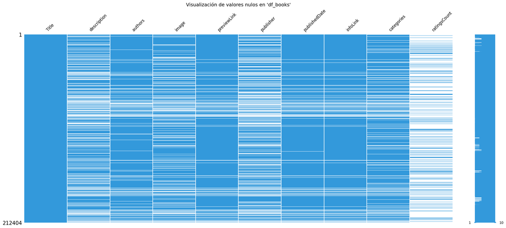

```python
plt.figure(figsize=(8, 5))
msno.matrix(df_books, fontsize=12, color=(0.2, 0.6, 0.86))
plt.title("Visualización de valores nulos en 'df_books'", fontsize=14)
plt.show()
```

La visualización muestra claramente los resultados obtenidos en la tabla anterior relacionado con la presencia de valores nulos (líneas blancas) en varias columnas del `df_books`. Aunque la columna `Title` está completa, otras como `description`, `authors`, `categories` y `image` tienen una alta proporción de celdas vacías, lo que podría limitar análisis basados en contenido o metadatos.

*Valores faltantes del Dataset: Ratings*

```python
df_reviews.isnull().sum()
```

|  | 0 |
| --- | --- |
| Id | 0 |
| Title | 208 |
| Price | 2518829 |
| User_id | 561787 |
| profileName | 561905 |
| review/helpfulness | 0 |
| review/score | 0 |
| review/time | 0 |
| review/summary | 407 |
| review/text | 8 |

**dtype:** int64

El análisis de valores nulos para `df_reviews` revela que las columnas `Price`, `User_id` y `profileName` presentan una enorme cantidad de datos faltantes, con más de medio millón de valores nulos cada una. Aunque campos clave como `review/score`, `review/text` y `review/helpfulness` están casi completos (con muy pocos o ningún nulo), la falta de información en los identificadores de usuario y precios podría limitar seriamente los análisis relacionados con comportamiento de compra o segmentación de usuarios.

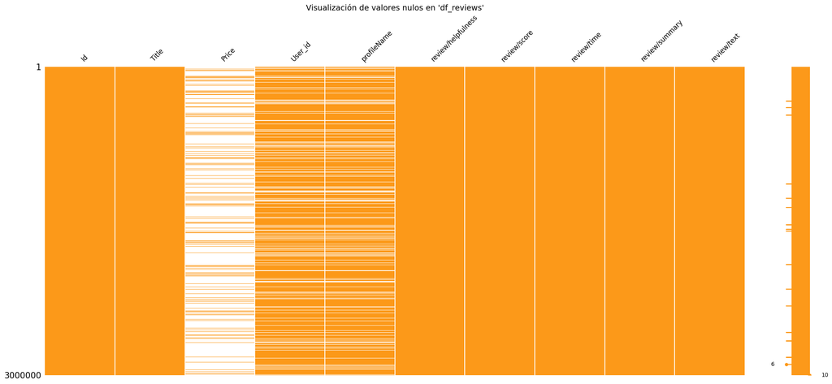

```python
# Visualización del patrón de nulos en reseñas
plt.figure(figsize=(8, 5))
msno.matrix(df_reviews, fontsize=12, color=(0.99, 0.6, 0.1))
plt.title("Visualización de valores nulos en 'df_reviews'", fontsize=14)
plt.show()
```

La visualización de valores nulos en `df_reviews` confirma que las columnas `Price`, `User_id` y `profileName` presentan una gran cantidad de datos faltantes, mostrados como franjas blancas que se repiten a lo largo de casi todo el conjunto de datos. En contraste, campos fundamentales para el análisis de opiniones como `review/score`, `review/time`, `review/text` y `review/helpfulness` están prácticamente completos, lo cual es positivo para modelos de análisis de sentimientos o evaluación de productos.

*Limpieza de datos*

```python
# Revisar y eliminar duplicados exactos
duplicados = df_reviews.duplicated().sum()
print(f"\nDuplicados exactos encontrados en reseñas: {duplicados}")
if duplicados > 0:
    df_reviews = df_reviews.drop_duplicates()
    print("Duplicados eliminados.")
```

```
Duplicados exactos encontrados en reseñas: 8774
Duplicados eliminados.
```

```python
# Eliminar filas con NaN en columnas esenciales
df_reviews = df_reviews.dropna(subset=['Title', 'review/score', 'review/text'])
df_books = df_books.dropna(subset=['Title'])
print("Se eliminaron filas con valores nulos críticos en reseñas y libros.")
```

```
Se eliminaron filas con valores nulos críticos en reseñas y libros.
```

```python
# Unir por título (puedes usar merge on lowercase si hay inconsistencias de mayúsculas)
df_merged = pd.merge(df_reviews, df_books, on='Title', how='inner')
print(f"\nDataset combinado: {df_merged.shape}")
```

```
Dataset combinado: (2991010, 19)
```

```python
# --- LIMPIEZA DE CAMPO AUTHORS ---
# Convertir a string y extraer solo el primer autor
df_merged['authors'] = df_merged['authors'].astype(str)
df_merged['authors_clean'] = df_merged['authors'].str.extract(r"'?([^,\[\]]+)'?")

# Eliminar filas donde no se pudo extraer un autor válido
df_merged = df_merged.dropna(subset=['authors_clean'])

# Asegurarse de eliminar entradas literales como "nan"
df_merged = df_merged[df_merged['authors_clean'].str.lower() != 'nan']

# Reset index si lo necesitas
df_merged.reset_index(drop=True, inplace=True)
```

```python
# Mostrar resultado final
print("\nDatos limpios y combinados:")
print(df_merged.head())
```

```
Datos limpios y combinados:
           Id                           Title  Price         User_id  \
0  1882931173  Its Only Art If Its Well Hung!    NaN   AVCGYZL8FQQTD
1  0826414346        Dr. Seuss: American Icon    NaN  A30TK6U7DNS82R
2  0826414346        Dr. Seuss: American Icon    NaN  A3UH4UZ4RSVO82
3  0826414346        Dr. Seuss: American Icon    NaN  A2MVUWT453QH61
4  0826414346        Dr. Seuss: American Icon    NaN  A22X4XUPKF66MR

                          profileName review/helpfulness  review/score  \
0               Jim of Oz "jim-of-oz"                7/7           4.0
1                       Kevin Killian              10/10           5.0
2                        John Granger              10/11           5.0
3  Roy E. Perry "amateur philosopher"                7/7           4.0
4     D. H. Richards "ninthwavestore"                3/3           4.0

```

[output cut: 48 more lines]

### d. Análisis de variables

*1. Distribución de puntajes*

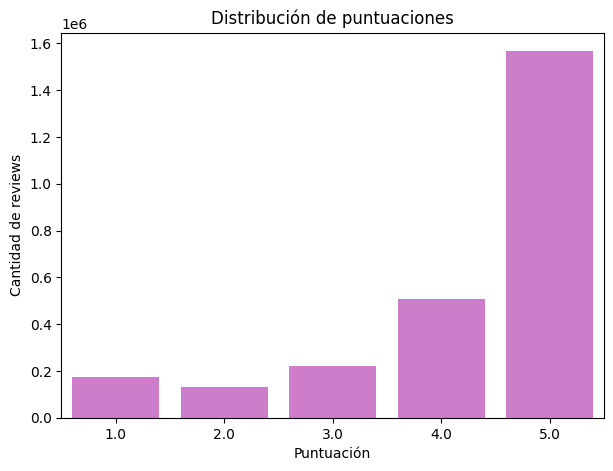

```python
# Distribución de puntajes
plt.figure(figsize=(7, 5))
sns.countplot(x='review/score', data=df_merged, color="orchid")
plt.title("Distribución de puntuaciones")
plt.xlabel("Puntuación")
plt.ylabel("Cantidad de reviews")
plt.show()
```

La gráfica de distribución de puntuaciones evidencia que la mayoría de los usuarios asignan la máxima calificación (5 estrellas) en sus reseñas, lo que representa una proporción significativamente mayor en comparación con el resto de las categorías. Las puntuaciones de 4 y 3 estrellas también aparecen en cantidades considerables, mientras que las de 1 y 2 estrellas son las menos frecuentes. Esta distribución indica un fuerte desbalance en los datos, donde las opiniones positivas predominan ampliamente sobre las negativas.

*2. Libros con más reseñas*

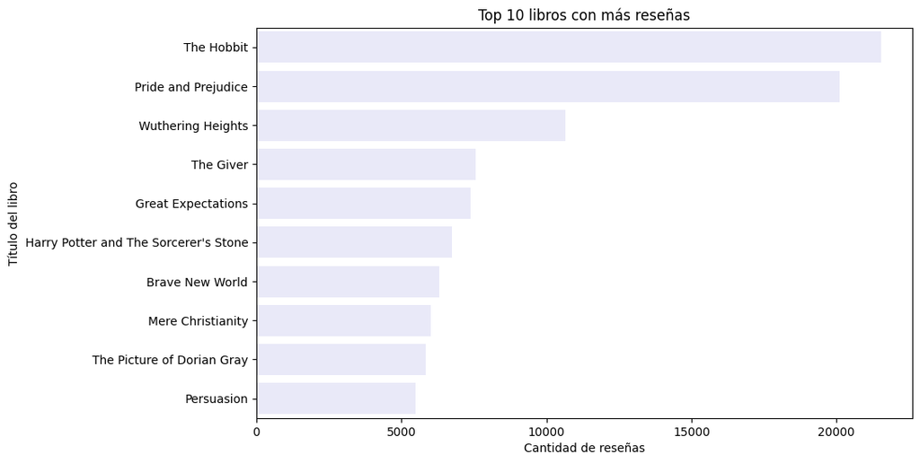

```python
top_books = df_merged['Title'].value_counts().head(10)

plt.figure(figsize=(10,6))
sns.barplot(y=top_books.index, x=top_books.values, color="lavender")
plt.title("Top 10 libros con más reseñas")
plt.xlabel("Cantidad de reseñas")
plt.ylabel("Título del libro")
plt.show()
```

Este ranking permite identificar los libros con mayor visibilidad y nivel de interacción por parte de los lectores. La presencia predominante de clásicos literarios y títulos populares sugiere que estos libros tienden a generar más comentarios y opiniones.

*3. Categorías más frecuentes*

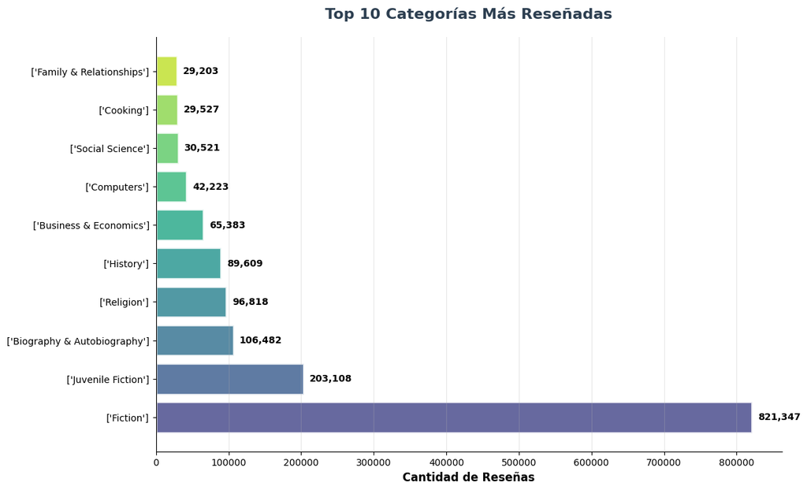

```python
top_cats = df_merged['categories'].value_counts().head(10)

plt.figure(figsize=(12,8))
colors = plt.cm.viridis(np.linspace(0.2, 0.9, len(top_cats)))
bars = plt.barh(top_cats.index, top_cats.values, color=colors, alpha=0.8, edgecolor='white', linewidth=2)
plt.title("Top 10 Categorías Más Reseñadas", fontsize=16, fontweight='bold', color='#2c3e50', pad=20)
plt.xlabel("Cantidad de Reseñas", fontsize=12, fontweight='bold')
for bar, val in zip(bars, top_cats.values): plt.text(bar.get_width() + max(top_cats.values)*0.01, bar.get_y() + bar.get_height()/2, f'{val:,}', va='center', fontweight='bold')
plt.gca().spines['top'].set_visible(False); plt.gca().spines['right'].set_visible(False); plt.grid(axis='x', alpha=0.3); plt.show()
```

*4. Autores con más reseñas*

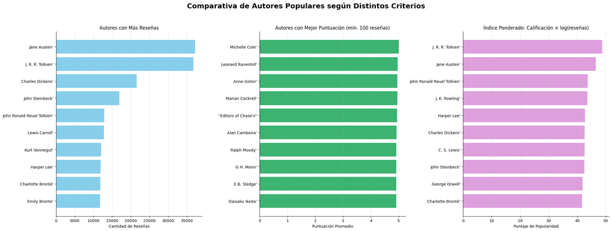

```python
# Asegurar tipo correcto y limpiar autor
df_merged['review/score'] = pd.to_numeric(df_merged['review/score'], errors='coerce')
df_merged['authors_clean'] = df_merged['authors'].astype(str).str.extract(r"'?([^,\[\]]+)'?")

# Calcular estadísticas por autor
author_stats = df_merged.groupby('authors_clean')['review/score'].agg(['mean', 'count'])
author_stats = author_stats[author_stats['count'] >= 10]  # para mayor confiabilidad
author_stats['popularity_score'] = author_stats['mean'] * np.log1p(author_stats['count'])

# Ranking 1: Más reseñas
top_by_reviews = author_stats.sort_values(by='count', ascending=False).head(10)

# Ranking 2: Mejor puntuación promedio (mín. 100 reseñas)
top_by_rating = author_stats[author_stats['count'] >= 100].sort_values(by='mean', ascending=False).head(10)

# Ranking 3: Índice ponderado
top_by_popularity = author_stats.sort_values(by='popularity_score', ascending=False).head(10)

# --- GRÁFICOS ---
fig, axes = plt.subplots(1, 3, figsize=(22, 8))
fig.suptitle("Comparativa de Autores Populares según Distintos Criterios", fontsize=18, fontweight='bold', y=1.03)

# 1. Más reseñas
axes[0].barh(top_by_reviews.index[::-1], top_by_reviews['count'][::-1], color='skyblue')
axes[0].set_title("Autores con Más Reseñas")
axes[0].set_xlabel("Cantidad de Reseñas")

# 2. Mejor puntuación promedio
axes[1].barh(top_by_rating.index[::-1], top_by_rating['mean'][::-1], color='mediumseagreen')
axes[1].set_title("Autores con Mejor Puntuación (mín. 100 reseñas)")
axes[1].set_xlabel("Puntuación Promedio")

# 3. Índice ponderado
axes[2].barh(top_by_popularity.index[::-1], top_by_popularity['popularity_score'][::-1], color='plum')
axes[2].set_title("Índice Ponderado: Calificación × log(reseñas)")
axes[2].set_xlabel("Puntaje de Popularidad")

# Ajustes
for ax in axes:
    ax.spines['top'].set_visible(False)
    ax.spines['right'].set_visible(False)
    ax.grid(axis='x', alpha=0.3)
    ax.tick_params(axis='y', labelsize=10)

plt.tight_layout()
plt.show()
```

Esta gráfica muestra una comparativa de los autores más populares según tres criterios diferentes:

**1. Autores con más reseñas**

Jane Austen y J. R. R. Tolkien son los autores con el mayor número de reseñas con más de 30,000 reseñas cada uno, lo que indica una fuerte presencia y nivel de lectura. Les siguen autores clásicos como Charles Dickens, John Steinbeck, Lewis Carroll y Charlotte Brontë, todos con más de 10,000 reseñas. Esto refleja la perdurabilidad y vigencia de los clásicos de la literatura, especialmente en inglés, en los hábitos de lectura de los usuarios.

**2. Autores con mejor puntuación promedio (min. 100 reseñas)**

Este panel presenta autores menos reconocidos popularmente, pero con una valoración muy alta (promedio cercano o igual a 5.0). Figuran nombres como Michelle Cole, Leonard Ravenhill, Anne Golon, o incluso editoriales como "Editors of Chase's". Esto sugiere que, aunque no tienen tantas reseñas como los autores del primer panel, sí cuentan con una audiencia altamente satisfecha. Sin embargo, este criterio mide la calidad percibida, pero no necesariamente popularidad en términos de volumen.

**3. Índice de popularidad ponderado: puntuación x log(reseñas)**

Este ranking combina cantidad y calidad de manera más balanceada. J. R. R. Tolkien y Jane Austen encabezan nuevamente, seguidos por J. K. Rowling, Harper Lee, C. S. Lewis y George Orwell. Es interesante ver que esta métrica incluye tanto autores clásicos como contemporáneos, y favorece a quienes tienen muchas reseñas con buenas puntuaciones, penalizando a los que tienen pocas o muy bajas.

*5. Autores con menos reseñas*

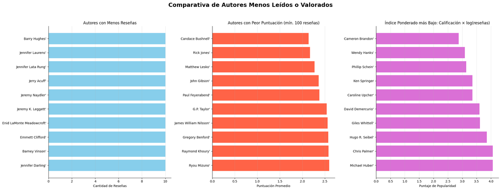

```python
# Asegúrate de que review/score sea numérico (por si acaso)
df_merged['review/score'] = pd.to_numeric(df_merged['review/score'], errors='coerce')

# Agrupar por autor limpio
author_stats = df_merged.groupby('authors_clean')['review/score'].agg(['mean', 'count'])
author_stats = author_stats[author_stats['count'] >= 10]  # umbral mínimo para evitar sesgos
author_stats['popularity_score'] = author_stats['mean'] * np.log1p(author_stats['count'])

# Ranking 1: Menos reseñas
bottom_by_reviews = author_stats.sort_values(by='count', ascending=True).head(10)

# Ranking 2: Peor puntuación promedio (mín. 100 reseñas)
bottom_by_rating = author_stats[author_stats['count'] >= 100].sort_values(by='mean', ascending=True).head(10)

# Ranking 3: Índice ponderado más bajo
bottom_by_popularity = author_stats.sort_values(by='popularity_score', ascending=True).head(10)

# --- GRÁFICOS ---
fig, axes = plt.subplots(1, 3, figsize=(22, 8))
fig.suptitle("Comparativa de Autores Menos Leídos o Valorados", fontsize=18, fontweight='bold', y=1.03)

# 1. Menos reseñas
axes[0].barh(bottom_by_reviews.index[::-1], bottom_by_reviews['count'][::-1], color='skyblue')
axes[0].set_title("Autores con Menos Reseñas")
axes[0].set_xlabel("Cantidad de Reseñas")

# 2. Peor puntuación promedio
axes[1].barh(bottom_by_rating.index[::-1], bottom_by_rating['mean'][::-1], color='tomato')
axes[1].set_title("Autores con Peor Puntuación (mín. 100 reseñas)")
axes[1].set_xlabel("Puntuación Promedio")

# 3. Índice ponderado más bajo
axes[2].barh(bottom_by_popularity.index[::-1], bottom_by_popularity['popularity_score'][::-1], color='orchid')
axes[2].set_title("Índice Ponderado más Bajo: Calificación × log(reseñas)")
axes[2].set_xlabel("Puntaje de Popularidad")

# Ajustes
for ax in axes:
    ax.spines['top'].set_visible(False)
    ax.spines['right'].set_visible(False)
    ax.grid(axis='x', alpha=0.3)
    ax.tick_params(axis='y', labelsize=10)

plt.tight_layout()
plt.show()
```

La gráfica muestra los autores menos leídos o valorados. Esta visualización complementa muy bien el análisis de los más populares, permitiendo entender qué autores han tenido menor impacto o peor recepción.

**1. Autores con menos reseñas**

Este grupo incluye autores como Barry Hughes, Jennifer Laurens, Jeremy K. Leggett y Jennifer Darling, todos con apenas unas 10 reseñas. Estos autores podrían ser relativamente desconocidos o estar vinculados a publicaciones de nicho, poco difundidas o poco accesibles. La baja visibilidad no implica necesariamente una mala calidad, pero sí una limitada circulación o alcance.

**2. Autores con peor puntuación promedio (mín. 100 reseñas)**

Este panel muestra autores que han recibido una cantidad razonable de reseñas pero con bajas puntuaciones, generalmente inferiores a 2.5 en promedio. Destacan nombres como Candace Bushnell, Rick Jones, Matthew Lesko, John Gibson, y Paul Feyerabend. Estos autores enfrentan una recepción crítica más negativa, lo cual puede deberse a varios factores: estilo de escritura, expectativas incumplidas, contenido controversial o edición deficiente. Este grupo es particularmente relevante, ya que sus libros sí llegaron a una audiencia considerable, pero no lograron una buena aceptación.

**3. Índice ponderado más bajo**

El índice combina cantidad de reseñas y puntuación media. Aquí aparecen autores como Cameron Brandon, Wendy Hanks, David Demercurio, y Michael Huber, que tienen tanto baja visibilidad como baja valoración. Esto refleja un impacto general bajo en la comunidad lectora. Es importante mencionar que este criterio penaliza doble: poca exposición y mala recepción.

*6. WordCloud de reseñas*

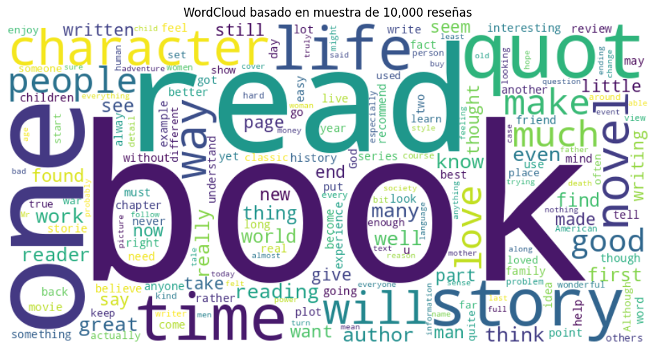

```python
# Tomar una muestra aleatoria de 10,000 reseñas
sample_text = " ".join(df_merged['review/text'].dropna().sample(10000, random_state=42).astype(str))

# Generar WordCloud
wc = WordCloud(width=800, height=400, background_color='white').generate(sample_text)

plt.figure(figsize=(12,6))
plt.imshow(wc, interpolation='bilinear')
plt.axis('off')
plt.title("WordCloud basado en muestra de 10,000 reseñas")
plt.show()
```

Las palabras más grandes (y por tanto más repetidas) son: "book", "read", "one", "story", "time", "character", "novel", "life", "people", y "quote".

Esto indica que los lectores suelen comentar sobre:

- La experiencia de leer (read, time, page, reader)
- Opiniones sobre la historia (story, plot, life)
- Elementos del libro (character, writing, author, chapter)
- Impacto emocional o reflexivo (love, thought, understand, feel)

Se nota una fuerte orientación hacia la experiencia personal de lectura y la valoración de la historia y sus personajes. Términos como "make", "feel", "find", "know", y "see" muestran que los lectores tienden a relacionarse con lo que el libro les provoca, más que solo describirlo objetivamente.

*7. Libros con el mayor número de reseñas*

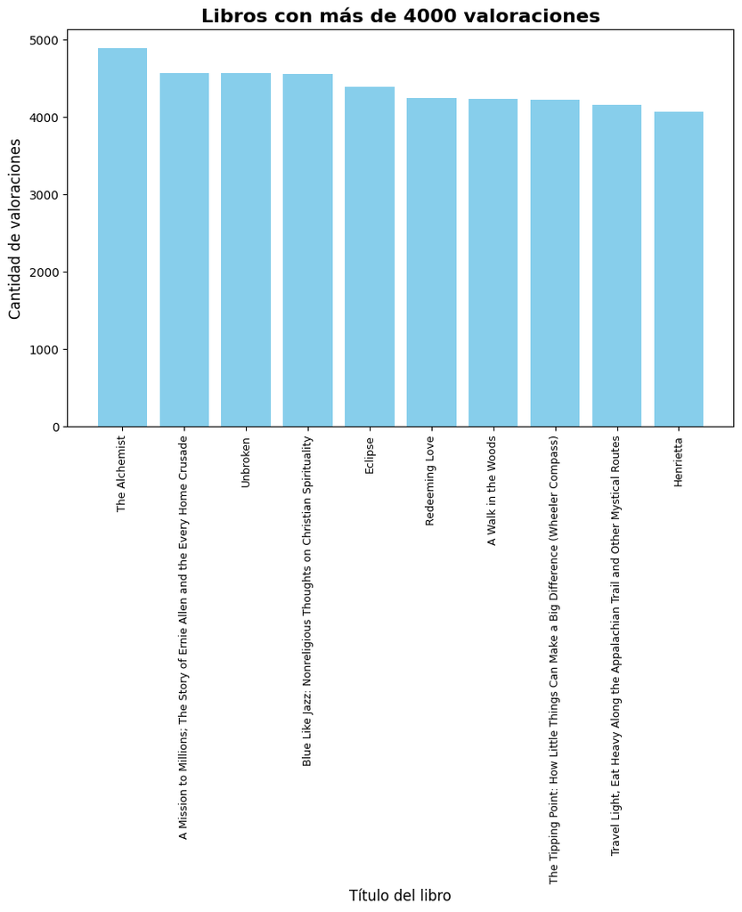

```python
# Filtramos libros con más de 4000 ratings únicos
rating_counts = df_merged[df_merged['ratingsCount'] > 4000][['Title', 'ratingsCount']].drop_duplicates()

# Ordenamos por ratingsCount descendente (opcional)
rating_counts = rating_counts.sort_values(by='ratingsCount', ascending=False)

# Plot
plt.figure(figsize=(10, 6))
plt.bar(rating_counts['Title'], rating_counts['ratingsCount'], color='skyblue')
plt.title('Libros con más de 4000 valoraciones', fontsize=16, weight='bold')
plt.xlabel('Título del libro', fontsize=12)
plt.ylabel('Cantidad de valoraciones', fontsize=12)

# Rótulos del eje x en vertical y más compactos
plt.xticks(rotation=90, fontsize=9, ha='center')  # ha = horizontalalignment
plt.tight_layout()
plt.show()
```

Este grupo de libros representa los títulos con mayor alcance y nivel de respuesta por parte de la audiencia. Esta métrica (cantidad de valoraciones) refleja nivel de exposición, popularidad comercial, y posiblemente presencia en medios o programas de lectura.

*8. Rating promedio por género de libros*

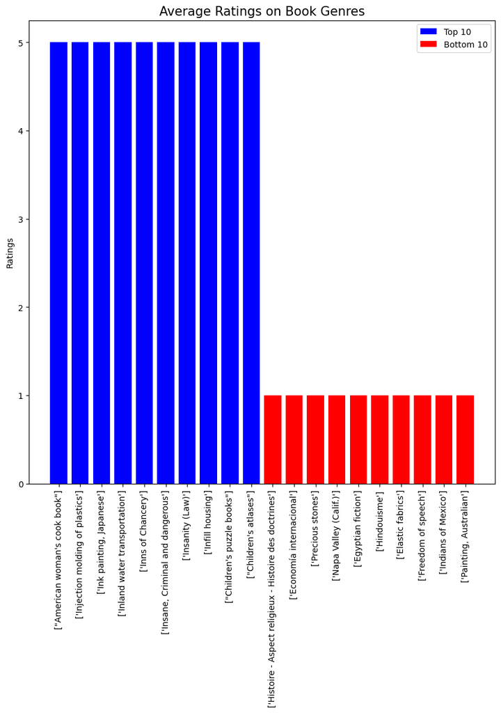

```python
# Convert 'review/score' column to numeric (if applicable)
df_merged['review/score'] = pd.to_numeric(df_merged['review/score'], errors='coerce')

# Filter out non-numeric values (if any)
numeric_data = df_merged.dropna(subset=['review/score'])

# Group by 'categories' and compute the mean of 'review/score'
avg_cat_rating = numeric_data.groupby('categories')['review/score'].mean().sort_values(ascending=False).head(10)
avg_cat_rating_d = numeric_data.groupby('categories')['review/score'].mean().sort_values().head(10)

# Plot the bar chart for top and bottom categories
plt.figure(figsize=(10, 10))
plt.bar(avg_cat_rating.index, avg_cat_rating, color='blue', label='Top 10')
plt.bar(avg_cat_rating_d.index, avg_cat_rating_d, color='red', label='Bottom 10')
plt.title('Average Ratings on Book Genres', fontsize=15)
plt.xticks(rotation='vertical')
plt.ylabel('Ratings')
plt.legend()
plt.show()
```

El gráfico muestra los géneros de libros con mejores y peores calificaciones promedio. Los diez géneros mejor valorados, en azul, tienen una puntuación perfecta de 5.0, lo que sugiere que fueron altamente apreciados por sus lectores, aunque probablemente cuentan con pocas reseñas. Entre ellos destacan temas específicos como cocina, derecho, arte japonés y libros infantiles. En contraste, los diez géneros peor valorados, en rojo, tienen calificaciones cercanas a 1.0, e incluyen temáticas como piedras preciosas, libertad de expresión o pintura australiana. Este contraste sugiere una diferencia significativa en la percepción del valor o calidad entre nichos temáticos, posiblemente influida por la cantidad limitada de reseñas en ambos extremos.

*9. Distribución del precio por puntuación*

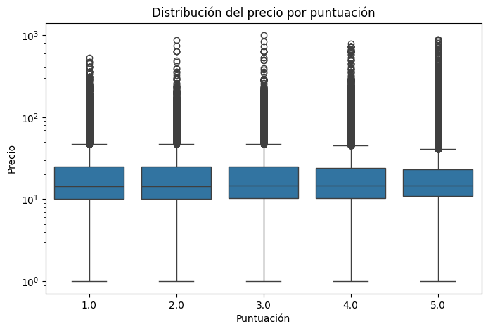

```python
plt.figure(figsize=(8,5))
sns.boxplot(x='review/score', y='Price', data=df_merged)
plt.title("Distribución del precio por puntuación")
plt.xlabel("Puntuación")
plt.ylabel("Precio")
plt.yscale('log')  # Para visualizar mejor precios extremos
plt.show()
```

El gráfico de cajas muestra la distribución de precios de libros agrupados por su puntuación, utilizando una escala logarítmica en el eje vertical. Se observa que, en general, el rango de precios es similar en todos los niveles de puntuación, con una mediana que oscila entre los 10 y 20 dólares. La dispersión es amplia y constante en todos los grupos, con numerosos valores atípicos (outliers) por encima de los 100 dólares. Esto indica que no existe una relación clara entre el precio del libro y la puntuación que recibe, ya que libros caros o baratos pueden encontrarse en cualquier nivel de valorción.

*10 . Matriz de correlación entre variables numéricas*

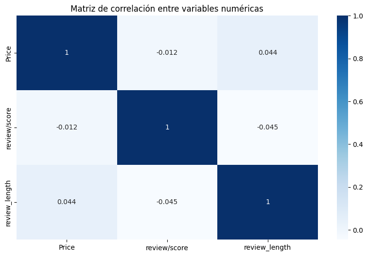

```python
df_merged['review_length'] = df_merged['review/text'].str.len()
plt.figure(figsize=(10,6))
sns.heatmap(df_merged[['Price', 'review/score', 'review_length']].corr(), annot=True, cmap='Blues')
plt.title("Matriz de correlación entre variables numéricas")
plt.show()
```

La matriz de correlación muestra que no hay relaciones significativas entre las variables numéricas analizadas: `Price`, `review/score` y `review_length`. Todas las correlaciones son muy cercanas a cero:

- **Precio vs. Puntuación**: -0.012 → correlación negativa muy débil, prácticamente nula.
- **Precio vs. Longitud de la reseña**: 0.044 → correlación positiva débil, sin relevancia estadística.
- **Puntuación vs. Longitud de la reseña**: -0.045 → leve tendencia negativa, también insignificante.

Esto indica que el precio de un libro, la longitud de la reseña y la puntuación dada por los usuarios son variables independientes entre sí en este conjunto de datos. En consecuencia, no se justifica usar una como predictor directo de otra sin un análisis más profundo o técnicas no lineales.

## Sistema de Recomendaciones

Los sistemas de recomendación hoy en día son parte fundamental de las plataformas digitales. Estos permiten personalizar la experiencia del usuario sugiriendo productos, contendio o servicios relevantes. A continuación se presentan tres sistemas de recomendación:

1. **Recomendación basada en contendio:** sugiere libros similares analizando el texto del título, descripción, autor y categorías utilizando lenguaje natural (TF-IDF+similitud de cosenos)
2. **Recomendación colaborativa:** recomienda libros que tuvieron buenas valoraciones por parte de los usarios ocn gustos similares, utilizando una matriz usuario-libro y medidas de similitud.
3. **Recomendación basada en un enfoque híbrido:** Combina los métodos anteriores para generar recomendaciones más precisas y robustas.

#### a. Sistema de Recomendación Basado en Contenido

*Preparación de los datos*

```python
# Importar librerias
from sklearn.feature_extraction.text import TfidfVectorizer
from sklearn.metrics.pairwise import linear_kernel

# Filtrar libros con suficientes ratings y contenido
df_books_filtered = df_books[df_books['ratingsCount'] > 100].dropna(subset=['description']).copy()
df_books_filtered = df_books_filtered.head(5000).reset_index(drop=True)  # limitar a 5000 libros para rendimiento y resetear el indice

# Combinar contenido textual
df_books_filtered['description'] = df_books_filtered['description'].fillna('')
df_books_filtered['categories'] = df_books_filtered['categories'].fillna('')
df_books_filtered['authors'] = df_books_filtered['authors'].fillna('')
df_books_filtered['Title'] = df_books_filtered['Title'].fillna('')

df_books_filtered['content'] = (
    df_books_filtered['Title'] + ' ' +
    df_books_filtered['categories'] + ' ' +
    df_books_filtered['description'] + ' ' +
    df_books_filtered['authors']
)
```

*TF-IDF y similitud*

```python
# Vectorizar con TF-IDF
tfidf = TfidfVectorizer(stop_words='english')
tfidf_matrix = tfidf.fit_transform(df_books_filtered['content'])

# Calcular similitud coseno
cosine_sim = linear_kernel(tfidf_matrix, tfidf_matrix)
```

*Función de recomendación*

```python
# Índice para búsqueda rápida
indices = pd.Series(df_books_filtered.index, index=df_books_filtered['Title']).drop_duplicates()

# Función de recomendación
def recomendar_libros(title, num_recommendations=5):
    if title not in indices:
        print(f"Libro '{title}' no encontrado en el subconjunto. Pruebe con otro.")
        # Sugerir algunos títulos disponibles si el libro no se encuentra
        print("\nAlgunos libros disponibles:")
        print(df_books_filtered['Title'].sample(5).to_string(index=False))
        return pd.DataFrame()

    idx = indices[title]
    sim_scores = list(enumerate(cosine_sim[idx]))
    sim_scores = sorted(sim_scores, key=lambda x: x[1], reverse=True)[1:num_recommendations+1]
    book_indices = [i[0] for i in sim_scores]

    return df_books_filtered[['Title', 'authors', 'categories']].iloc[book_indices]
```

*Ejemplo de uso*

```python
# Ejemplo de uso
recomendar_libros("The Clan of the Cave Bear")
```

|  | Title | authors | categories |
| --- | --- | --- | --- |
| 370 | Everything Is Illuminated : A Novel | ['Jonathan Safran Foer'] | ['Fiction'] |
| 147 | The Widow | ['Fiona Barton'] | ['Fiction'] |
| 150 | The story of art | ['Ernst Hans Gombrich'] | ['Art'] |
| 233 | Wide Sargasso Sea | ['Jean Rhys'] | ['Fiction'] |
| 264 | Prodigal Summer by Kingsolver (hardcover edition) | ['Barbara Kingsolver'] | ['Fiction'] |

La tabla muestra los resultados del sistema de recomendaciones para el libro **"The Clan of the Cave Bear"**. Podemos observar que de las recomendacioness cuatro de las cinco recomendaciones están en la categoría de "ficción", lo que sugiere que el libro seleccionado para la recomendación muy probablemente sea de ficción. Esto se alinea bien con el sistema de recomendación basado en contenido. Adicionalmente, cada libro recomendado es de un autor diferente, lo que sugiere que el sistema de recomendación no sobreajusta a un solo autor.

Por otra parte, el hecho de que recomiende "The Story of Art" por Gombrich que es el único libro en la categoría de "arte" sugiere que es un match parcial basado en otro tipo de metadata (e.g. palabras claves en el título o contenido). Así mismo, se podría dar que el sistema no filtra por una sola categoría.

La lista incluye libros de ficción contemporánea ("The Widow") y trabajos clásicos o postcoloniales ("Wide Sargasso Sea"), lo que impolica que hay un proceso semántico o temático en el proceso de emparejamiento.

#### b. Sistema de Recomendación Basado en Ratings

*Preparar y crear la matriz usuario-libro*

```python
# Importar librerias
from sklearn.metrics.pairwise import cosine_similarity
from scipy.sparse import csr_matrix

# Filtrar usuarios y libros activos
df_collab = df_merged[['User_id', 'Title', 'review/score']].dropna()

# Usuarios con más de 20 valoraciones
user_counts = df_collab['User_id'].value_counts()
active_users = user_counts[user_counts > 20].index

# Libros con más de 30 valoraciones
title_counts = df_collab['Title'].value_counts()
popular_books = title_counts[title_counts > 30].index

# Subset final
filtered_df = df_collab[
    df_collab['User_id'].isin(active_users) &
    df_collab['Title'].isin(popular_books)
]

# Paso 2: Matriz usuario x libro
user_item_matrix = filtered_df.pivot_table(index='User_id', columns='Title', values='review/score').fillna(0)

# Limitar a 1000x1000 para rendimiento
user_item_matrix = user_item_matrix.iloc[:1000, :1000]

# Convertir a matriz esparsa
user_item_sparse = csr_matrix(user_item_matrix.values)
```

*Calcular la similitud entre usuarios*

```python
# Calcular similitud entre usuarios
user_sim = cosine_similarity(user_item_sparse)
user_sim_df = pd.DataFrame(user_sim, index=user_item_matrix.index, columns=user_item_matrix.index)
```

*Función de recomendación colaborativa*

```python
# Función de recomendación

def recomendar_colaborativamente(user_id, num_recommendations=5):
    if user_id not in user_item_matrix.index:
        print("Usuario no encontrado en el subconjunto.")
        return pd.DataFrame()

    # Usuarios similares
    similar_users = user_sim_df[user_id].sort_values(ascending=False)[1:]

    # Ratings ponderados por similaridad
    aligned_similar_users = similar_users.reindex(user_item_matrix.index).fillna(0)
    weighted_scores = user_item_matrix.T.dot(aligned_similar_users) / similar_users.sum()


    # Libros que el usuario no ha calificado
    user_rated_books = user_item_matrix.loc[user_id]
    unseen_books = weighted_scores[user_rated_books[user_rated_books == 0].index]

    return unseen_books.sort_values(ascending=False).head(num_recommendations).reset_index(name='Estimated Score')
```

*Ejemplo de uso*

```python
# Ejemplo de uso
print("Usuarios disponibles:")
print(user_item_matrix.index.to_list()[:5])  # mostrar ejemplos

# Ejecutar con un usuario de prueba
recomendar_colaborativamente(user_item_matrix.index[0])
```

```
Usuarios disponibles:
['A01038432MVI9JXYTTK5T', 'A101446I5AWY0Z', 'A101DG7P9E26PW', 'A103U0Q3IKSXHE', 'A103W7ZPKGOCC9']
```

|  | Title | Estimated Score |
| --- | --- | --- |
| 0 | A Tale of Two Cities, Literary Touchstone Edition | 0.772339 |
| 1 | A tale of two cities | 0.772339 |
| 2 | A Tale of Two Cities - Literary Touchstone Edi... | 0.772339 |
| 3 | 1632 (The Assiti Shards) | 0.379927 |
| 4 | A Town Like Alice | 0.327441 |

La tabla representa los principales resultados del sistema de recomendaciones basado en rankings, dónde los puntajes son proporcionados para un usuario especifico para varios libros.

El sistema de recomendación asigna alta confianza (≈0.77) a el libro *A tale of Two Cities*. Esto sugiere una preferencia o interés predicho en ese libro en específico o en ese autor (Charles Dickens), probablemente basado en interacciones previas del usuario (rating explicitos o comportamiento implícito). No obstante, es importante revisar las entradas de los libros debido a que la repetición por diferentes ediciones puede inflar la lista de recomendaciones y reducir la diversidad del contenido recomendado.

Adicionalmente, hay un disminución del puntaje estimado de ~0.77 a ~0.38 y luego a ~0.33. Esto implica que más allá del libro *A tale of Two Cities*, el modelo tiene una confianza baja en el interés del usuario con los libros restantes. Esta distribución es típica cuando el perfil de preferencias del usuario es reducido o la señal colaborativa es baja para el resto de libros.

#### c. Sistema de Recomendación Hibrido

*Versión híbrida simplificada (libro → contenido → afinidad colaborativa)*

```python
def recomendar_hibrido(title, num_recommendations=5):
    # Paso 1: Recomendaciones por contenido (TF-IDF)
    idx = indices.get(title)
    if idx is None:
        print("Libro no encontrado.")
        return pd.DataFrame()

    sim_scores = list(enumerate(cosine_sim[idx]))
    sim_scores = sorted(sim_scores, key=lambda x: x[1], reverse=True)[1:50]  # tomar los 50 más parecidos
    book_indices = [i[0] for i in sim_scores]

    # Subconjunto de libros similares
    content_df = df_books_filtered.iloc[book_indices][['Title', 'authors', 'categories']].copy()

    # Paso 2: Cruzar con puntuaciones promedio de usuarios (del sistema colaborativo)
    # Solo si el libro también está en la matriz colaborativa
    rating_avgs = user_item_matrix.mean(axis=0)
    content_df['estimated_score'] = content_df['Title'].map(rating_avgs).fillna(0)

    # Paso 3: Ordenar y devolver los mejores
    return content_df.sort_values(by='estimated_score', ascending=False).head(num_recommendations)
```

*Ejemplo de uso*

```python
recomendar_hibrido("The Hobbit", num_recommendations=5)
```

|  | Title | authors | categories | estimated_score |
| --- | --- | --- | --- | --- |
| 246 | And then there were none | ['Agatha Christie'] | ['Fiction'] | 0.067 |
| 691 | 1,000 Places to See Before You Die: A Traveler... | ['Patricia Schultz'] | ['Travel'] | 0.024 |
| 241 | ANNIHILATION | ['Jeff VanderMeer'] | ['Fiction'] | 0.000 |
| 570 | The Hobbit There and Back Again | ['John Ronald Reuel Tolkien'] | ['Adventure stories'] | 0.000 |
| 150 | The story of art | ['Ernst Hans Gombrich'] | ['Art'] | 0.000 |

Los resultados representan el sistema de confianza de los intereses potenciales del lector en cada libro. Las recomendaciones son de libros con diferentes géneros: ficción (Christie, VanderMeer), Travel (Schultz), and art (Gombrich). Esta diversidad en el contenido sugiere que el sistema híbrido está activo, al utilizar información de diferentes categorías y autores basado en characterísticas temáticas o de perfiles.

El sístema regresa una lista de libros recomendados amplia pero débil en cuanto a los puntajes estimados, posiblemente para un usuario con poca o ningún tipo de actividad. A pesar de que captura una gran variedad de contenido a lo largo de diferentes géneros, el interés entre los títulos es mínimo. El libro que encabeza el ranking (*And Then There Were None*) posiblemente comparte characterísticas (e.g. género o popularidad) con libros marcados positivamente por el usuario.

## Clusters de texto

El clustering de texto es una técnica de aprendizaje no supervisado que nos permite agrupar textos similares en clusters o grupos. Utilizamos clustering para descubrir temas o tópicos comunes en las reseñas de los libros.

Para realizar el proceso, se desarrollan 4 pasos:

1. **Preprocesamiento de texto:** Limpiar y preparar el texto de las reseñas (eliminar stopwords, puntuación, etc.).
2. **Vectorización:** Convertir el texto en vectores numéricos (usando técnicas como TF-IDF).
3. **Aplicación del algoritmo de clustering:** Aplicar un algoritmo de clustering como K-Means para agrupar los textos en clusters.
4. **Análisis de los clusters:** Analizar los clusters resultantes para entender los temas o tópicos que representan.

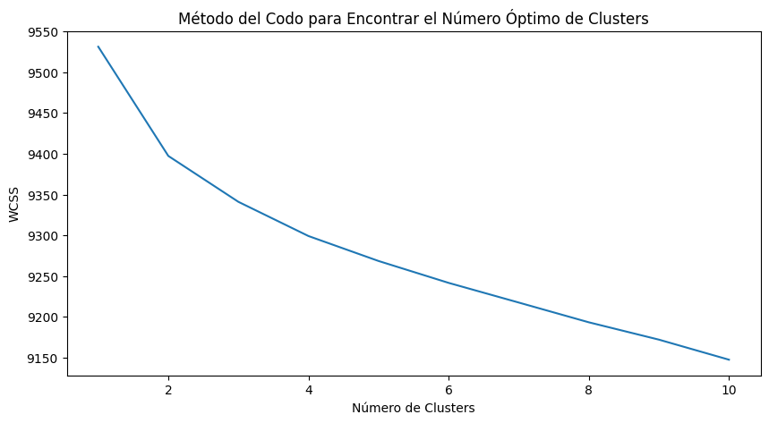

```python
from sklearn.feature_extraction.text import TfidfVectorizer
from sklearn.cluster import KMeans
from sklearn.decomposition import PCA
import matplotlib.pyplot as plt

# Tomar una muestra de 10,000 reseñas para el clustering
df_cluster = df_merged.sample(10000, random_state=42)

# Preprocesamiento y vectorización
vectorizer = TfidfVectorizer(stop_words='english', max_features=1000)
X = vectorizer.fit_transform(df_cluster['review/text'])

# Encontrar el número óptimo de clusters usando el método del codo
wcss = []
for i in range(1, 11):
    kmeans = KMeans(n_clusters=i, init='k-means++', max_iter=300, n_init=10, random_state=0)
    kmeans.fit(X)
    wcss.append(kmeans.inertia_)

# Graficar el método del codo
plt.figure(figsize=(10, 5))
plt.plot(range(1, 11), wcss)
plt.title('Método del Codo para Encontrar el Número Óptimo de Clusters')
plt.xlabel('Número de Clusters')
plt.ylabel('WCSS') # Within cluster sum of squares
plt.show()
```

El gráfico utiliza el método del codo para ayudar a determinar el número óptimo de clusters (k) en el dataset para clusters con k-medias. El eje vertical representa WCSS (la suma total de cuadrados dentro del cluster). Esta medición determina que tan compacto son los clusters, un WCSS más bajo implica clusters más ajustados.

La curva muestra un decrecimiento gradual en el WCSS a medida que el número de clusters aumenta de 1 a 10. La caida más grande se da entre k=1 y k=2, y hay un retorno decreciente en la reducción de WCSS a medida que k aumenta. El punto dónde se da el codo aparece cerca de k=2 o k=3.

```
Top terms per cluster:
Cluster 0:
 quot
 book
 read
 like
 time
 story
 books
 novel
 just
 good

Cluster 1:
 story
 book
 novel
 characters
 life
 love
 like
 read
 just
 time

Cluster 2:
 read
 book
 books
 reading
 good
 just
 like
 great
 time
 ve

Cluster 3:
 book
 great
 good
 like
 just
 reading
 books
 time
 read
 author
```

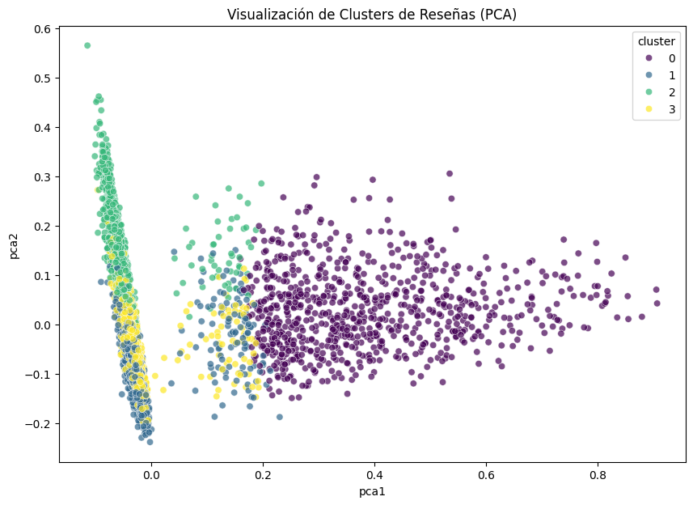

```python
# Aplicar K-Means con el número óptimo de clusters (e.g., 4)
n_clusters = 4
kmeans = KMeans(n_clusters=n_clusters, init='k-means++', max_iter=300, n_init=10, random_state=0)
df_cluster['cluster'] = kmeans.fit_predict(X)

# Analizar los clusters
print("Top terms per cluster:")
order_centroids = kmeans.cluster_centers_.argsort()[:, ::-1]
terms = vectorizer.get_feature_names_out()
for i in range(n_clusters):
    print(f"Cluster {i}:")
    for ind in order_centroids[i, :10]:
        print(f" {terms[ind]}")
    print()

# Visualizar los clusters
pca = PCA(n_components=2, random_state=0)
X_pca = pca.fit_transform(X.toarray())
df_cluster['pca1'] = X_pca[:, 0]
df_cluster['pca2'] = X_pca[:, 1]

plt.figure(figsize=(10, 7))
sns.scatterplot(x='pca1', y='pca2', hue='cluster', data=df_cluster, palette='viridis', alpha=0.7)
plt.title('Visualización de Clusters de Reseñas (PCA)')
plt.show()
```

El resultado muestra las palabras más representativas (temas dominantes) en cada uno de los cuatro clusters generados a partir de reseñas de libros.

1. **Cluster 0: Enfocado en citas y opiniones breves**:
- Palabras claves: `quot`, `book`, `read`, `like`, `just`, `good`, `time`.
- Este cluster agrupa reseñas que incluyen o comentan citas del libro (`quot` probablemente viene de "quote"). Es común también en reseñás breves donde los usuarios destacan frases puntutales, o hacen juicios rápidos del tipo "*just read this, it was good*".
2. **Cluster 1: Narrativa y personajes**:
- Palabras claves: `story`, `novel`, `characters`, `life`, `love`, `like`, `read`.
- Este cluster agrupa reseñas que se centran en la trama y los personajes. Palabras como `characters`, `life`, y `love` indican que el contenido suele comentar sobre temas humanos, emocionales o reflexivos, estos son comúnes en novelas de ficción.
3. **Cluster 2: Experiencia de lectura general**:
- Palabras claves: `read`, `book`, `books`, `reading`, `good`, `just`, `like`, `great`.
- Este cluster agrupa reseñas que se centran en la experiencia personal de lectura, donde los usuarios usan frases genéricas pero positivas, como "*just finished reading this, great book!*". La repetición de `read`, `reading`, y `books` sugiere una valoración global del hábito de lectura más que del contenido específico.
4. **Cluster 3: Evaluaciones generales y autor**:
- Palabras claves: `book`, `great`, `good`, `like`, `just`, `reading`, `author`.
- Este cluster es similar al anterior pero con un enfasis adicional en el autor. Son predominantes los juicios globales sobre la obra y el escritor, lo que sugiere que las reseñas pueden estar enfocadas en la calidad general, estilo del autor o comparación con otros libros del mismo.

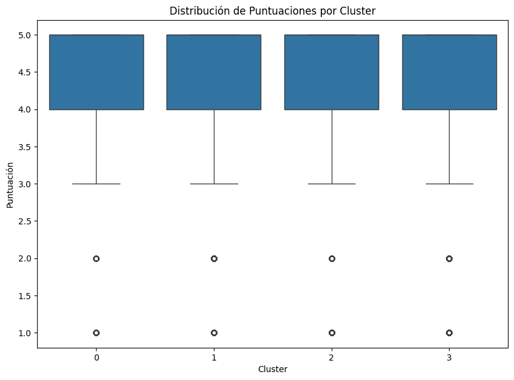

```python
plt.figure(figsize=(10, 7))
sns.boxplot(x='cluster', y='review/score', data=df_cluster)
plt.title('Distribución de Puntuaciones por Cluster')
plt.xlabel('Cluster')
plt.ylabel('Puntuación')
plt.show()
```

El gráfico muestra un diagrama de cajas, y por ende la distribución de puntuaciones por cluster de reseñas, permitiéndonos analizar si existen diferencias en la valoración de los libros entre los distintos grupos temáticos de reseñas previamente identificados.

En general, todos los clusters (0, 1, 2 y 3) tienen una mediana de puntuación de 5, lo que indica que la mayoría de las reseñas, sin importar su tipo, son altamente positivas. El rango intercuartíl (Q1 a Q3) está concentrado entre 4 y 5 en todos los clusters. Todos los grupos tienen valores atípicos (outliers) en todos los grupos, lo que sugiere que las reseñas con puntuación de 1 o 2, son bajas.

Más aún, aunque los clusters representan distintos estilos o enfoques de reseña (citas, narrativa, experiencia de lectura, opinión sobre el autor), las puntuaciones que otorgan los usuarios no varían sustancialmente entre grupos. Esto sugiere que el lenguaje o el contenido de las reseñas no está fuertemente correlacionado con la puntuación numérica, al menos no de forma directa.

Este análisis confirma que la mayoría de las reseñas en todos los clusters son positivas, con puntuaciones altas (4 o 5). Si bien existen algunas reseñas negativas, estas se distribuyen de manera uniforme entre los grupos. Por tanto, aunque los clusters ayudan a identificar distintos enfoques discursivos, no sirven para predecir fácilmente la calificación del usuario.

## Análisis de Sentimientos

```python
# Cargamos el analizador de texto VADER
vader = SentimentIntensityAnalyzer()
```

```python
# Convertir el texto de la reseñas a minúsculas
df_merged['clean_reviews'] = df_merged['review/text'].str.lower()
# Calcular el puntaje de polarización de las reseñas
df_merged['score'] = df_merged['clean_reviews'].apply(lambda review: vader.polarity_scores(review))
# Extraer el puntaje de sentimiento global
df_merged['compound']  = df_merged['score'].apply(lambda score_dict: score_dict['compound'])
```

```python
# Clasifica el sentimiento
# Compound value: > 0.05 = positivo; < -0.05 negativo; entre -0.05 y 0.05 = neutral
data['Sentiment'] = data['compound'].apply(lambda x: 'positive' if x >= 0.05 else 'negative' if x < -0.05 else 'neutral')
data.head()
```

El sistema de análisis de sentimiento está funcionando correctamente: detecta el tono del texto y lo clasifica correctamente la mayoría de los casos como `positive` cuando la calificación es alta. Sin embargo, pueden haber casos como la reseña del libro Mayflower dónde a pesar de que el usuario otorgó una puntuación baja, su reseña es crítica pero mantuvo un lenguaje objetivo.

### a. Distribución de sentimientos negativos, neutrales y positivos en la base de datos

[figure not shown]

```python
# Create a figure and subplots with 1 row and 2 columns
plt.figure(figsize=(12, 5))

# Plot 1 - Pie chart for sentiment distribution
plt.subplot(1, 2, 1)
labels = ['Positive', 'Negative', 'Neutral']
sizes = df_merged['Sentiment'].value_counts()
colors = ['green', 'red', 'blue']
explode = (0.1, 0.1, 0.1)

plt.pie(sizes, explode=explode, labels=labels, colors=colors, autopct='%1.1f%%', shadow=True)
plt.title('Distribución de sentimientos')

# Plot 2 - Histograma para la distribución de sentimientos
plt.subplot(1, 2, 2)
positive = df_merged[df_merged['compound'] > 0]['compound']
negative = df_merged[df_merged['compound'] < 0]['compound']
neutral = df_merged[df_merged['compound'] == 0]['compound']

sentiments = [positive, negative, neutral]
colors = ['green', 'red', 'orange']
labels = ['Positive Sentiments', 'Negative Sentiments', 'Neutral Sentiments']

for sentiment, color, label in zip(sentiments, colors, labels):
    plt.hist(sentiment, bins=20, color=color, alpha=0.5, label=label)

plt.title('Distribución de sentimientos')
plt.xlabel('Puntaje Global')
plt.ylabel('No. de reseñas')
plt.legend()

plt.tight_layout()
plt.show()
```

Los gráficos muestran que la mayoría de las reseñas (82.5%) tienen un sentimiento positivo, seguidas por un 15.6% negativas y solo un 2% son neutrales. Esto indica una fuerte tendencia de satisfacción entre los lectores con referente a los libros en la base de datos. Adicionalmente, el gráfico de barras muestra que la mayoría de los valores de sentimiento compuesto están cerca de 1, confirmando que las reseñas tienden a ser muy positivas. Las reseñas negativas se agrupan en el extremo opuesto, pero son menos frecuentes.

[figure not shown]

```python
df_merged['Sentiment'].value_counts().plot(kind = 'bar', figsize = (8,5))
plt.xticks(rotation = 'horizontal')
plt.title('Sentiment Distribution',fontsize = 15)
plt.grid()
plt.show()
```

El gráfico corrobora lo encontrado en los gráficos anteriores. En el se visualiza claramente que la mayoría de las reseñas son positivas en comparación con las negativas y las neutrales. Esto refuerza que la recepción de los libros es altamente favorable.

*Mayor número de reseñas positivas por libro*

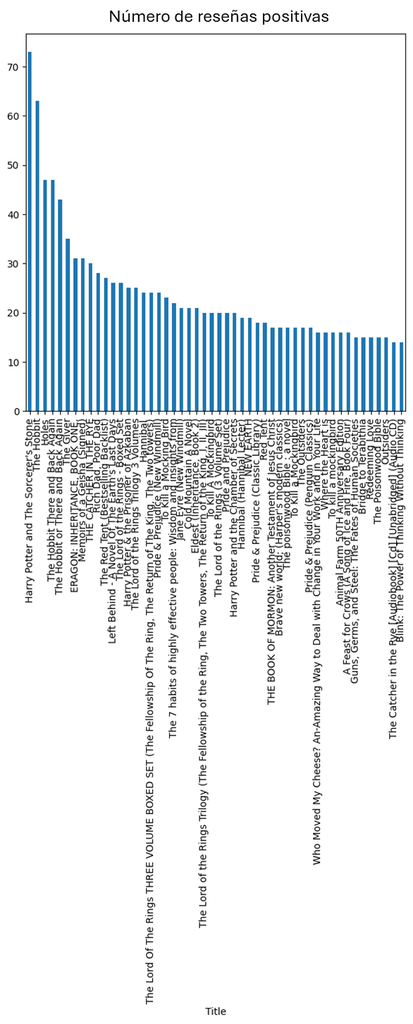

```python
df_merged[df_merged['Sentiment'] == 'positive']['Title'].value_counts().head(50).plot(kind = 'bar', figsize = (5,6))
plt.title('Número de reseñas positivas',fontsize = 15)
plt.xticks(rotation = 90)
plt.show()
```

*Mayor número de reseñas neutrales por libro*

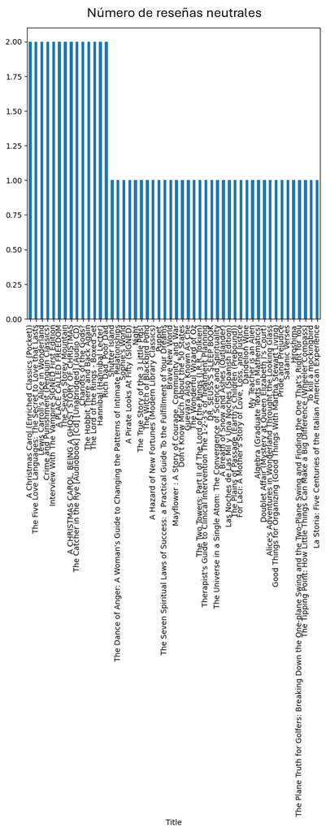

```python
df_merged[df_merged['Sentiment'] == 'neutral']['Title'].value_counts().head(50).plot(kind = 'bar', figsize = (7,7))
plt.title('Número de reseñas neutrales',fontsize = 15)
plt.xticks(rotation = 90)
plt.show()
```

De acuerdo con el gráfico, el máximo número de reseñas neutrales que tiene cualquier libro es 2. El resto de libros tienen 1 reseña neutral cada uno. No hay libros con más de 2 ni con 0 reseñas neutrales en el gráfico. No obstante, es importante mencionar que las reseñas neutrales en general son pocas, e igual para cada libro: no hay casos donde un libro concentre muchas opiniones neutrales. Esto último sugiere que en la muestra original, los usuarios suelen dar reseñas más positivas o negativas, y las neutrales son minoritarias.

*Mayor número de reseñas negativas por libro*

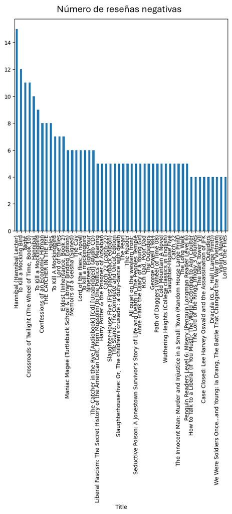

```python
df_merged[df_merged['Sentiment'] == 'negative']['Title'].value_counts().head(50).plot(kind = 'bar', figsize = (7,7))
plt.title('Número de reseñas negativas',fontsize = 15)
plt.xticks(rotation = 90)
plt.show()
```

De acuerdo con la gráfica, el libro con más reseñas negativas es "Hannibal", con 15 reseñas negativas. Hay otros títulos con valores negativos "Crossroads of Twilight", "Confessions of an Economic Hitman". Hacia la derecha del gráfico, la cantidad de reseñas negativas disminuye gradualmente hasta llegar a los libros con 4 reseñas negativas. En general, la distribución es asimétrica, pocos libros concentran muchas reseñas negativas mientras que la mayoría tienen valores moderados o bajos.

### b. Dataframe de reseñas y sentimientos

```python
reviews_sent = df_merged[['clean_reviews', 'Sentiment']]
reviews_sent.head()
```

### c. Dividir los datos entre x & y

```python
x = reviews_sent.drop(['Sentiment'], axis=1)
y = reviews_sent['Sentiment']
```

```python
x.shape
```

```python
y.shape
```

## Procesamiento y Clasificación de Texto

```python
# Descargar paquetes
nltk.download('stopwords')
nltk.download('wordnet')
nltk.download('omw-1.4')

# Importar librerias
import re
stemmer = nltk.SnowballStemmer("english")
from nltk.corpus import stopwords
import string
stopword=set(stopwords.words('english'))
import subprocess

from nltk.stem import WordNetLemmatizer
from nltk.tokenize import word_tokenize
from nltk.tokenize.toktok import ToktokTokenizer
from nltk.stem import LancasterStemmer,WordNetLemmatizer
import re, string, unicodedata
from string import punctuation
```

Utilizamos cuatro funciones para limpiar y procesar el texto antes de analizarlo.

```python
# Elimina URLs
def hapus_url(text):
    return re.sub(r'http\S+','', text)

# Eliminar caracteres especiales
def remove_special_characters(text, remove_digits=True):
    pattern=r'[^a-zA-Z0-9\s]'
    text=re.sub(pattern,'',text)
    return text

#Aplicar lematización a cada palabra
def lemmi(text):
    lemmatizer = WordNetLemmatizer()
    text=' '.join([lemmatizer.lemmatize(word) for word in text.split()])
    return text

# Filtrado final: elimina stopwords, convierte todo a minúsculas, mantiene solo palabras
def final_clean(text):
    final_text= []
    for i in text.split():
        if i.strip().lower() not in stopword and i.strip().lower().isalpha():
            final_text.append(i.strip().lower())
    return " ".join(final_text)
```

```python
# Definimos la función clean con todas las funciones anteriores
def clean(text):
    text = hapus_url(text)
    text = remove_special_characters(text, remove_digits=True)
    text = lemmi(text)
    text = final_clean(text)
    return text
```

```python
# Aplicar las funciones a la base de datos
x["clean_reviews"] = x["clean_reviews"].apply(clean)
```

### a. Definir conjunto de prueba y de entrenamiento

```python
# Separar datos de entrenamiento y prueba
x_train, x_test, y_train, y_test = train_test_split(x, y, test_size=0.25,random_state=0)
x_train
```

```python
# Vectorizar TF-IDF
x_train_tfidf = tfidf_vectorizer.fit_transform(x_train['clean_reviews'])

# Transformar la columna clean_reviews' en los datos de testeo
x_test_tfidf = tfidf_vectorizer.transform(x_test['clean_reviews'])
```

### b. Balancear los datos

```python
# Utilizamos SMOTE (synthetic Minority Oversampling Technique) para balancear las clases en el conjunto de entrenamiento
oversample = SMOTE()
x_train_bal, y_train_bal = oversample.fit_resample(x_train_tfidf, y_train)
y_train_bal.value_counts()
```

```
Sentiment
positive    9273
negative    9273
neutral     9273
Name: count, dtype: int64
```

La salida indica que el conjunto de entrenamiento está perfectamente balanceado. Cada clase (positiva, negativa, neutral) tiene exactamente el mismo número de ejemplos 9,273

```python
# Aplicamos SMOTE al conjunto de prueba
x_test_bal, y_test_bal = oversample.fit_resample(x_test_tfidf, y_test)
y_test_bal.value_counts()
```

```
Sentiment
positive    3098
negative    3098
neutral     3098
Name: count, dtype: int64
```

Al igual que en el conjunto de entrenamiento, el conjunto de prueba se encuentra balanceado en cada clase de sentimiento con 3.098 ejemplos.

### c. Entrenar los modelos

1. Regresión Logística

```python
log = LogisticRegression()
log.fit(x_train_tfidf_df, y_train)
```

```
LogisticRegression()
```

```python
perd_log=log.predict(x_test_tfidf_df)
```

```python
print(classification_report(perd_log, y_test))
```

```
              precision    recall  f1-score   support

    negative       0.22      0.85      0.35       150
     neutral       0.00      0.00      0.00         0
    positive       0.99      0.85      0.92      3600

    accuracy                           0.85      3750
   macro avg       0.41      0.57      0.42      3750
weighted avg       0.96      0.85      0.90      3750
```

*Aplicar la regresion logística a los datos balanceados*

```python
log_bal = LogisticRegression()
log_bal.fit(x_train_bal, y_train_bal)
```

```
LogisticRegression()
```

```python
perd_log_bal =log_bal.predict(x_test_bal)
```

```python
print(classification_report(perd_log_bal, y_test_bal))
```

```
              precision    recall  f1-score   support

    negative       0.71      0.68      0.70      3227
     neutral       0.08      0.85      0.14       278
    positive       0.92      0.49      0.64      5789

    accuracy                           0.57      9294
   macro avg       0.57      0.67      0.49      9294
weighted avg       0.82      0.57      0.64      9294
```

De acuerdo con los resultados, podemos observar que hubo un cambio con respecto a la versión no balanceada. Las métricas de precision and recall están equilibradas con 0.71 y 0.68, respectivamente. El modelo ahora si predice los sentimientos negativos, mejor que antes.

```python
confusion_matrix(y_test_bal,perd_log_bal)
```

```
array([[2198,   23,  877],
       [ 786,  237, 2075],
       [ 243,   18, 2837]])
```

```
<sklearn.metrics._plot.confusion_matrix.ConfusionMatrixDisplay at 0x788e893b9e40>
```

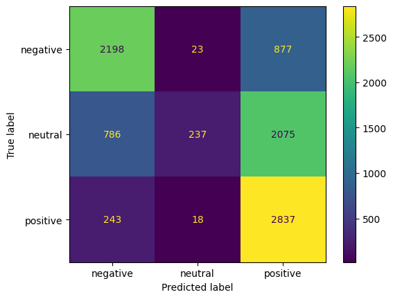

```python
cm = confusion_matrix(y_test_bal, perd_log_bal, labels=log.classes_)
disp = ConfusionMatrixDisplay(confusion_matrix=cm,display_labels=log.classes_)
disp.plot()
```

La situación es diferente con la clase neutral. De las reseñas neutrales solo 237 fueron clasificadas correctamente, mientras que 2,075 fueron clasificadas como positivas y 786 como negativas. Esto implica que el modelo no ha aprendido a reconocer el patrón lingüístico de la neutralidad y en cambio tiende a forzarlo hacia clases extremas.

En cuanto a las reseñas positivas, el modelo presenta una buena precisión clasificando correctamente 2,837 casos, y confundiendo únicamente 243 con negativos y 18 con neutrales. Esto confirma que el modeloo tiene una inclinación a predecir las reseñas de manera positiva, ya que es la categoría con el mayor número de predcciones correctas y mayor cantidad de predicciones incorrectas de otras clases.

2. Árbol de Decisión

```python
classifier= DecisionTreeClassifier(criterion='entropy', random_state=45)
classifier.fit(x_train_tfidf_df, y_train)
```

```
DecisionTreeClassifier(criterion='entropy', random_state=45)
```

```python
pred_tre = classifier.predict(x_test_tfidf_df)
```

```python
print(classification_report(pred_tre, y_test))
```

```
              precision    recall  f1-score   support

    negative       0.34      0.35      0.34       556
     neutral       0.15      0.19      0.17        64
    positive       0.87      0.86      0.87      3130

    accuracy                           0.78      3750
   macro avg       0.45      0.47      0.46      3750
weighted avg       0.78      0.78      0.78      3750
```

Para el modelo de árbol de decisión entrenado con datos desbalanceados, los resultados sugieren que la clase positiva obtiene mejores resultados. El precision para esta clase es de 0.87 y el recall es de 0.86, el modelo predice esta categoría con un alto grado de acierto. Esto se traduce en un F1-score alto (0.87), lo que sugiere que en la clase positiva se concentra la mayor parte del rendimiento del modelo. Esto podría explicarse por la presencia de los datos de entrenamiento en el modelo.

Más aún, las clases negativa y neutral muestran un renidmiento mucho más bajo. En la clase negativa el precision y el recall son 0.34 y 0.35, respectivamente. Esto sugiere que el modelo confunde con frecuencia los negativos con positivos y no logra recuperar más de un tercio de los casos reales. Por otra parte en la clase neutral, el recall es de 0.19 y el precision de 0.15, lo que implica que la mayoría de reseñas son clasificadas erróneamente. Esto nos da indicios de que el modelo aún no logra encontrar patrones diferenciadores para estas categorias.

En general el accuracy muestra un buen puntaje (0.78), pero podría estar inflado por la clase positiva. El marco promedio (0.45 de precision y 0.47 de recall) revela un rendimiento desigual entre las clases, mientras que el promedio ponderado (0.78) es alto porque le da mucho peso a la clase positiva.

```python
confusion_matrix(y_test,pred_tre)
```

```
array([[ 193,   10,  369],
       [  13,   12,   55],
       [ 350,   42, 2706]])
```

```
<sklearn.metrics._plot.confusion_matrix.ConfusionMatrixDisplay at 0x788e88c81750>
```

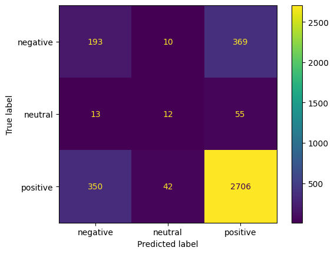

```python
cm = confusion_matrix(y_test, pred_tre, labels=classifier.classes_)
disp = ConfusionMatrixDisplay(confusion_matrix=cm,display_labels=classifier.classes_)
disp.plot()
```

La matriz de confusión refleja claramente lo que vimos en las métricas del árbol de decisión desbalanceado. El modelo predice bien los positivos, pero tiene grandes dificultades para distinguir los negativos y, sobre todo, los neutrales.

En general, el modelo enfoca sus predicciones hacia la clase positiva, usándola como "clase por defecto" cuando no tiene certeza. Las clases minoritarias (negativa y neutral) tienen la mayoría de sus ejemplos son absorbidos como positivos. Esto ocurre porque los árboles de decisión, al entrenarse con datos desbalanceados, tienden a favorecer la clase más frecuente en las divisiones.

Aunque el accuracy total es 0.78, este valor es engañoso, ya que depende casi por completo del desempeño en la clase positiva. El árbol desbalanceado no está aprendiendo patrones claros para distinguir negativos y neutrales, lo que lo convierte en un modelo poco útil si se busca un análisis equilibrado del sentimiento.

*Aplicar árbol de decisión a los datos balanceados*

```python
classifier_bal= DecisionTreeClassifier(criterion='entropy', random_state=45)
classifier_bal.fit(x_train_bal, y_train_bal)
```

```
DecisionTreeClassifier(criterion='entropy', random_state=45)
```

```python
pred_tre_bal = classifier_bal.predict(x_test_bal)
```

```python
print(classification_report(pred_tre_bal, y_test_bal))
```

```
              precision    recall  f1-score   support

    negative       0.51      0.52      0.52      3013
     neutral       0.14      0.62      0.23       712
    positive       0.81      0.45      0.58      5569

    accuracy                           0.49      9294
   macro avg       0.49      0.53      0.44      9294
weighted avg       0.66      0.49      0.53      9294
```

```python
confusion_matrix(y_test_bal,pred_tre_bal)
```

```
array([[1578,  171, 1349],
       [ 937,  442, 1719],
       [ 498,   99, 2501]])
```

```
<sklearn.metrics._plot.confusion_matrix.ConfusionMatrixDisplay at 0x788e88c6f310>
```

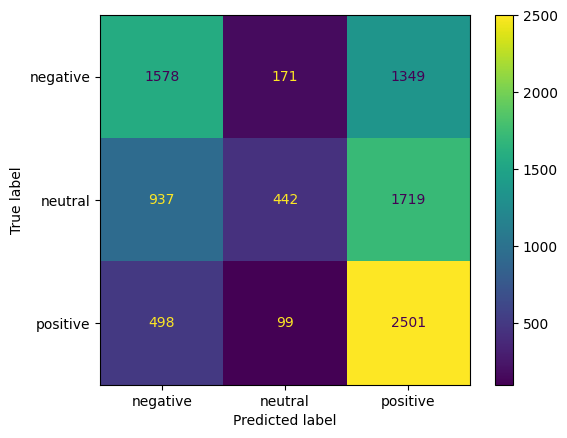

```python
cm = confusion_matrix(y_test_bal, pred_tre_bal, labels=classifier.classes_)
disp = ConfusionMatrixDisplay(confusion_matrix=cm,display_labels=classifier.classes_)
disp.plot()
```

El árbol de decisión, incluso balanceado, no es lo suficientemente potente para distinguir bien entre los tres tipos de sentimiento, en especial la clase neutral. La matriz de confusión refleja el cambio en el comportamiento del modelo.

En la clase negativa, el modelo logra identificar correctamente alrededor de la mitad de los casos (1,578 aciertos), aunque sigue confundiendo una gran cantidad de reseñas negativas con positivas (1,349). La clase neutral, que en el modelo desbalanceado casi no era reconocida, ahora logra identificar 442 casos neutrales. Sin embargo, la mayoría de las reseñas de esta categoría siguen siendo clasificadas como positivas (1,719) o negativas (937). El modelo es capaz de "atrapar" más casos neutrales, pero se equivoca mucho generando demasiados falsos positivos. En cuanto a la clase positiva, que antes era la dominante, se observa una caída en el rendimiento. No obstante, la clase mantiene un buen número de aciertos (2,501), pero con algunas confusiones: 498 positivos se clasificaron como negativos y 99 como neutrales.

En conjunto, el balanceo permitió que el modelo fuera más justo entre clases, evitando que la clase positiva monopolizara las predicciones. Sin embargo, el costo fue una disminución notable de la exactitud global (49%) y un empeoramiento en la separación de las clases, en particular entre neutrales y positivos.

3. Naive Bayes

```python
nb = GaussianNB()
nb.fit(x_train_tfidf_df, y_train)
```

```
GaussianNB()
```

```python
pred_nb = nb.predict(x_test_tfidf_df)
```

```python
print(classification_report(pred_nb, y_test))
```

```
              precision    recall  f1-score   support

    negative       0.29      0.15      0.20      1086
     neutral       0.04      0.09      0.05        34
    positive       0.70      0.83      0.76      2630

    accuracy                           0.63      3750
   macro avg       0.34      0.36      0.34      3750
weighted avg       0.58      0.63      0.59      3750
```

Estos resultados del modelo Naive Bayes entrenado con datos desbalanceados muestran un patrón claro: el clasificador se adapta principalmente a la clase mayoritaria (positive), mientras que las clases minoritarias (negative y, sobre todo, neutral) quedan prácticamente ignoradas.

En la clase positiva, el rendimiento es alto. Con una precisión de 0.70 y un recall de 0.83, el modelo es capaz de identificar correctamente la gran mayoría de reseñas positivas y, además, la mayoría de sus predicciones en esta categoría son acertadas. El F1-score de 0.76 confirma que esta clase domina el desempeño global del modelo, lo cual es consistente con que representa la mayor parte de los datos de entrenamiento.

*Aplicar Naive Bayes a los datos balanceados*

```python
# Assuming x_train_bal is your sparse matrix
x_train_bal_dense = x_train_bal.toarray()

# Then proceed with fitting the model using the dense array
nb_bal = GaussianNB()
nb_bal.fit(x_train_bal_dense, y_train_bal)
```

```
GaussianNB()
```

```python
pred_nb_bal = nb_bal.predict(x_test_bal.toarray())
```

```python
print(classification_report(pred_nb_bal, y_test_bal))
```

```
              precision    recall  f1-score   support

    negative       0.21      0.26      0.23      2450
     neutral       0.00      0.28      0.01        43
    positive       0.71      0.32      0.44      6801

    accuracy                           0.31      9294
   macro avg       0.31      0.29      0.23      9294
weighted avg       0.57      0.31      0.38      9294
```

Los resultados muestran unos resultados completamente distintos al Naive Bayes desbalanceado. Al intentar equilibrar las clases, el modelo pierde mucha capacidad de generalización y su rendimiento disminuye considerablemente.

4. Random Forest

```python
from sklearn.ensemble import RandomForestClassifier
```

```python
x_train_tfidf_df.shape
```

```
(11250, 63144)
```

```python
x_test_tfidf_df.shape
```

```
(3750, 63144)
```

```python
ran=RandomForestClassifier(n_estimators=100)
ran.fit(x_train_tfidf_df,y_train)
```

```
RandomForestClassifier()
```

```python
perd_ran=ran.predict(x_test_tfidf_df)
```

```python
perd_ran.shape
```

```
(3750,)
```

```python
y_test.shape , perd_ran.shape
```

```
((3750,), (3750,))
```

```python
print(classification_report(perd_ran, y_test))
```

```
              precision    recall  f1-score   support

    negative       0.04      0.88      0.07        24
     neutral       0.00      0.00      0.00         0
    positive       1.00      0.83      0.91      3726

    accuracy                           0.83      3750
   macro avg       0.35      0.57      0.33      3750
weighted avg       0.99      0.83      0.90      3750
```

Excelente, este reporte del Random Forest entrenado en datos desbalanceados confirma un patrón que ya habíamos visto en los otros clasificadores: el modelo termina casi completamente dominado por la clase mayoritaria (positive), lo que genera métricas infladas en accuracy pero un pobre equilibrio entre clases.

```python
confusion_matrix(y_test,perd_ran)
```

```
array([[  21,    0,  551],
       [   1,    0,   79],
       [   2,    0, 3096]])
```

```
<sklearn.metrics._plot.confusion_matrix.ConfusionMatrixDisplay at 0x788e887baf80>
```

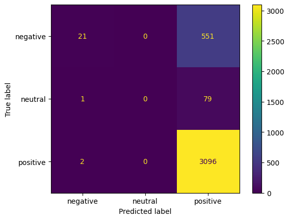

```python
cm = confusion_matrix(y_test, perd_ran, labels=ran.classes_)
disp = ConfusionMatrixDisplay(confusion_matrix=cm,display_labels=ran.classes_)
disp.plot()
```

*Aplicar Random Forest a los datos balanceados*

```python
ran_bal=RandomForestClassifier(n_estimators=100)
ran_bal.fit(x_train_bal,y_train_bal)
perd_ran_bal=ran_bal.predict(x_test_bal)
```

```python
print(classification_report(perd_ran_bal, y_test_bal))
```

```
              precision    recall  f1-score   support

    negative       0.44      0.78      0.57      1757
     neutral       0.00      0.67      0.00         3
    positive       0.96      0.40      0.56      7534

    accuracy                           0.47      9294
   macro avg       0.47      0.62      0.38      9294
weighted avg       0.87      0.47      0.56      9294
```

```python
confusion_matrix(y_test_bal,perd_ran_bal)
```

```
array([[1374,    1, 1723],
       [ 274,    2, 2822],
       [ 109,    0, 2989]])
```

```
<sklearn.metrics._plot.confusion_matrix.ConfusionMatrixDisplay at 0x788e89181960>
```

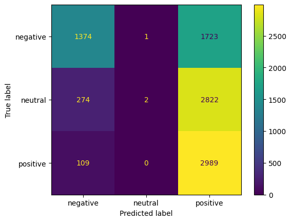

```python
cm = confusion_matrix(y_test_bal, perd_ran_bal, labels=ran.classes_)
disp = ConfusionMatrixDisplay(confusion_matrix=cm,display_labels=ran.classes_)
disp.plot()
```

En conjunto, el modelo muestra una fuerte tendencia a sobrepredecir la clase positiva, usándola como categoría por defecto, mientras que los neutrales prácticamente desaparecen y los negativos quedan divididos entre aciertos y falsos positivos hacia la clase mayoritaria.